# GSE96870, differential expression analysis

2021-07-19

# Load packages

```r
suppressPackageStartupMessages({
    library(SummarizedExperiment)
    library(DESeq2)
    library(ggplot2)
    library(ExploreModelMatrix)
    library(cowplot)
    library(ComplexHeatmap)
})
```

# Read data

```r
se <- readRDS("GSE96870_se.rds")
se
```

```
## class: RangedSummarizedExperiment
## dim: 41786 45
## metadata(0):
## assays(1): counts
## rownames(41786): Xkr4 LOC105243853 ... TrnT TrnP
## rowData names(4): gene ENTREZID product gbkey
## colnames(45): GSM2545336 GSM2545337 ... GSM2545379 GSM2545380
## colData names(10): title geo_accession ... tissue mouse
```

# Summary stats

```r
sort(colSums(assay(se, "counts")))
```

```
## GSM2545369 GSM2545365 GSM2545342 GSM2545338 GSM2545358 GSM2545339 GSM2545341
##   30803177   31073132   31624027   31684299   32662211   32663438   32777049
## GSM2545366 GSM2545359 GSM2545364 GSM2545340 GSM2545378 GSM2545346 GSM2545344
##   32873181   33334029   33436531   33518799   33554163   33642930   33726110
## GSM2545337 GSM2545377 GSM2545345 GSM2545375 GSM2545379 GSM2545373 GSM2545356
##   33818586   33907950   34043596   34514890   34836758   34854279   35043262
## GSM2545360 GSM2545354 GSM2545371 GSM2545347 GSM2545368 GSM2545363 GSM2545349
##   35377215   35470183   35657587   36130719   36342954   36499016   36643928
## GSM2545351 GSM2545348 GSM2545361 GSM2545372 GSM2545362 GSM2545353 GSM2545374
##   37224356   37698775   37905385   38017302   38546511   39520008   39615774
## GSM2545370 GSM2545343 GSM2545336 GSM2545380 GSM2545355 GSM2545357 GSM2545352
##   39917806   40031023   40265225   40921490   41728557   42166439   43189078
## GSM2545350 GSM2545367 GSM2545376
##   43409628   44803453   45343064
```

# Explore the design

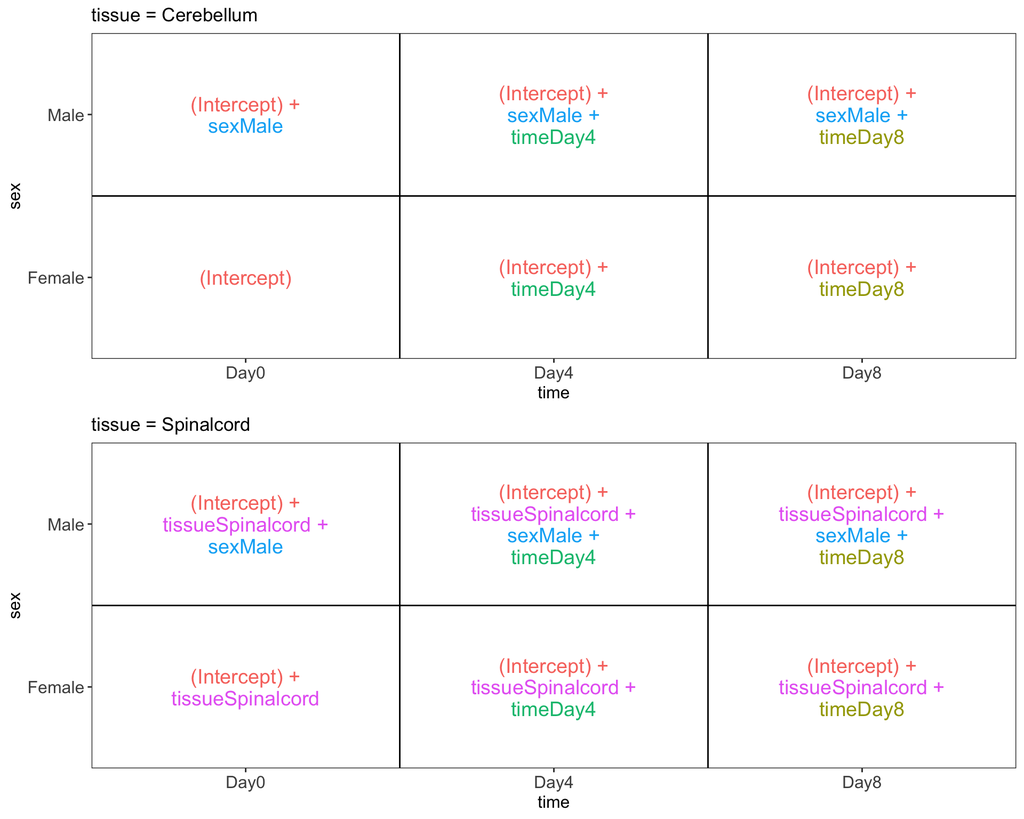

```r
res <- ExploreModelMatrix::VisualizeDesign(sampleData = colData(se),
                                           designFormula = ~ tissue + sex + time)
cowplot::plot_grid(plotlist = res$plotlist, nrow = 2)
```

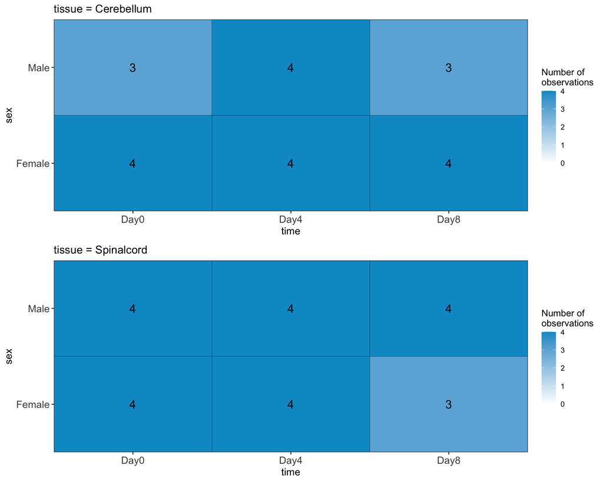

```r
cowplot::plot_grid(plotlist = res$cooccurrenceplots, nrow = 2)
```

# Save text files to use for lesson

```r
## Full count matrix
write.csv(cbind(gene = rownames(se), assay(se, "counts")),
          file = "GSE96870_counts_all.csv", row.names = FALSE,
          quote = FALSE)

## Full colData
write.csv(cbind(sample = colnames(se), colData(se)),
          file = "GSE96870_coldata_all.csv", row.names = FALSE,
          quote = FALSE)

## rowRanges, which includes rowData
write.table(cbind(seqnames = seqnames(rowRanges(se)),
                  start = start(rowRanges(se)), end = end(rowRanges(se)),
                  strand = strand(rowRanges(se)), mcols(rowRanges(se))),
          file = "GSE96870_rowranges.tsv", row.names=FALSE, sep="\t",
          quote=FALSE)

## Cerebellum count matrix
se_cereb <- se[, se$tissue == "Cerebellum"]
write.csv(cbind(gene = rownames(se_cereb), assay(se_cereb, "counts")),
          file = "GSE96870_counts_cerebellum.csv", row.names = FALSE,
          quote = FALSE)

## Cerebellum colData
write.csv(cbind(sample = colnames(se_cereb), colData(se_cereb)),
          file = "GSE96870_coldata_cerebellum.csv", row.names = FALSE,
          quote = FALSE)
```

# Create DESeqDataSet

```r
dds <- DESeq2::DESeqDataSet(se, design = ~ tissue + sex + time)
```

# PCA (variance-stabilized values)

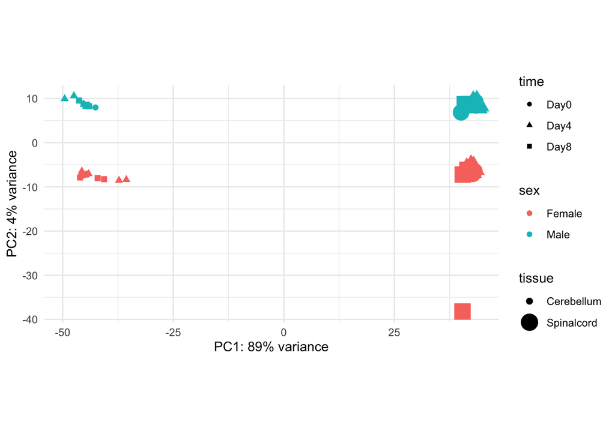

```r
vsd <- DESeq2::vst(dds, blind = TRUE)
pcaData <- DESeq2::plotPCA(vsd, intgroup = c("sex", "time", "tissue"),
                           returnData = TRUE)
percentVar <- round(100 * attr(pcaData, "percentVar"))
ggplot(pcaData, aes(x = PC1, y = PC2)) +
    geom_point(aes(color = sex, shape = time, size = tissue)) +
    theme_minimal() +
    xlab(paste0("PC1: ", percentVar[1], "% variance")) +
    ylab(paste0("PC2: ", percentVar[2], "% variance")) +
    coord_fixed()
```

# Subset to cerebellum samples and redo PCA

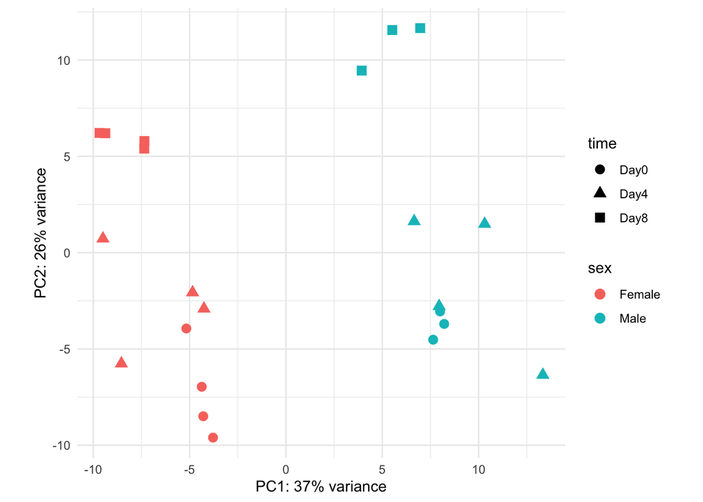

```r
dds <- DESeq2::DESeqDataSet(se[, se$tissue == "Cerebellum"],
                            design = ~ sex + time)
vsd <- DESeq2::vst(dds, blind = TRUE)
pcaData <- DESeq2::plotPCA(vsd, intgroup = c("sex", "time"),
                           returnData = TRUE)
percentVar <- round(100 * attr(pcaData, "percentVar"))
ggplot(pcaData, aes(x = PC1, y = PC2)) +
    geom_point(aes(color = sex, shape = time), size = 3) +
    theme_minimal() +
    xlab(paste0("PC1: ", percentVar[1], "% variance")) +
    ylab(paste0("PC2: ", percentVar[2], "% variance")) +
    coord_fixed()
```

# Differential expression

```r
dds <- DESeq2::DESeq(dds)
## Day 8 vs Day 0
resTime <- DESeq2::results(dds, contrast = c("time", "Day8", "Day0"))
summary(resTime)
```

```
##
## out of 32652 with nonzero total read count
## adjusted p-value < 0.1
## LFC > 0 (up)       : 4472, 14%
## LFC < 0 (down)     : 4276, 13%
## outliers [1]       : 10, 0.031%
## low counts [2]     : 8732, 27%
## (mean count < 1)
## [1] see 'cooksCutoff' argument of ?results
## [2] see 'independentFiltering' argument of ?results
```

```r
head(resTime[order(resTime$pvalue), ])
```

```
## log2 fold change (MLE): time Day8 vs Day0
## Wald test p-value: time Day8 vs Day0
## DataFrame with 6 rows and 6 columns
##                baseMean log2FoldChange     lfcSE      stat      pvalue
##               <numeric>      <numeric> <numeric> <numeric>   <numeric>
## Asl             701.343        1.11733 0.0592541   18.8565 2.59885e-79
## Apod          18765.146        1.44698 0.0805186   17.9708 3.30147e-72
## Cyp2d22        2550.480        0.91020 0.0554756   16.4072 1.69794e-60
## Klk6            546.503       -1.67190 0.1058989  -15.7877 3.78228e-56
## Fcrls           184.235       -1.94701 0.1279847  -15.2128 2.90708e-52
## A330076C08Rik   107.250       -1.74995 0.1154279  -15.1606 6.45112e-52
##                      padj
##                 <numeric>
## Asl           6.21386e-75
## Apod          3.94690e-68
## Cyp2d22       1.35326e-56
## Klk6          2.26086e-52
## Fcrls         1.39017e-48
## A330076C08Rik 2.57077e-48
```

```r
## Male vs Female
resSex <- DESeq2::results(dds, contrast = c("sex", "Male", "Female"))
summary(resSex)
```

```
##
## out of 32652 with nonzero total read count
## adjusted p-value < 0.1
## LFC > 0 (up)       : 53, 0.16%
## LFC < 0 (down)     : 71, 0.22%
## outliers [1]       : 10, 0.031%
## low counts [2]     : 13717, 42%
## (mean count < 6)
## [1] see 'cooksCutoff' argument of ?results
## [2] see 'independentFiltering' argument of ?results
```

```r
head(resSex[order(resSex$pvalue), ])
```

```
## log2 fold change (MLE): sex Male vs Female
## Wald test p-value: sex Male vs Female
## DataFrame with 6 rows and 6 columns
##                baseMean log2FoldChange     lfcSE      stat       pvalue
##               <numeric>      <numeric> <numeric> <numeric>    <numeric>
## Xist         22603.0359      -11.60429  0.336282  -34.5076 6.16852e-261
## Ddx3y         2072.9436       11.87241  0.397493   29.8683 5.08722e-196
## Eif2s3y       1410.8750       12.62514  0.565216   22.3369 1.62066e-110
## Kdm5d          692.1672       12.55386  0.593627   21.1477  2.89566e-99
## Uty            667.4375       12.01728  0.593591   20.2451  3.92780e-91
## LOC105243748    52.9669        9.08325  0.597624   15.1989  3.59432e-52
##                      padj
##                 <numeric>
## Xist         1.16739e-256
## Ddx3y        4.81378e-192
## Eif2s3y      1.02237e-106
## Kdm5d         1.37001e-95
## Uty           1.48667e-87
## LOC105243748  1.13371e-48
```

Save results so that specific genes can be selected when creating the intro course data.

```r
saveRDS(resTime, file = "resTime.rds")
saveRDS(resSex, file = "resSex.rds")
```

# MA plot

TODO: Add shrinkage

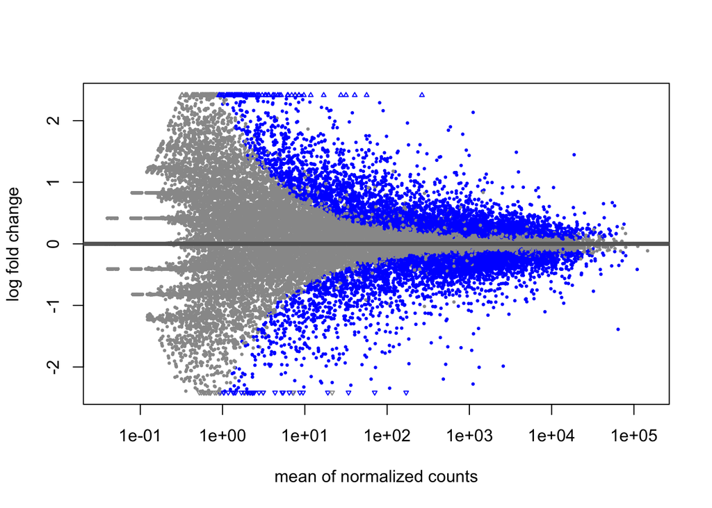

```r
DESeq2::plotMA(resTime)
```

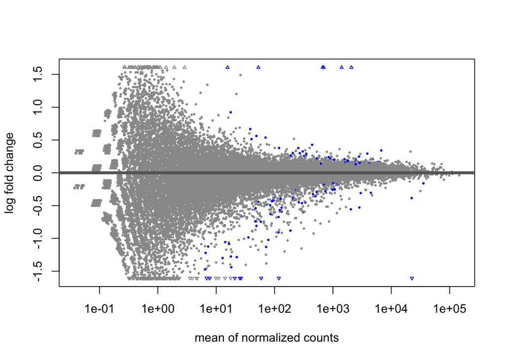

```r
DESeq2::plotMA(resSex)
```

# Heatmap

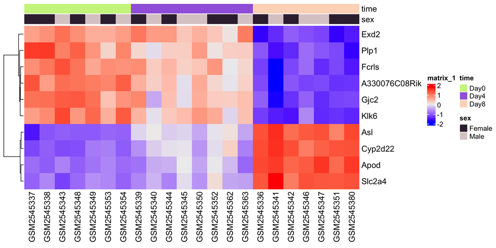

```r
genes <- rownames(head(resTime[order(resTime$pvalue), ], 10))
heatmapData <- assay(vsd)[genes, ]
heatmapData <- t(scale(t(heatmapData)))
heatmapColAnnot <- data.frame(colData(vsd)[, c("time", "sex")])

idx <- order(vsd$time)
heatmapData <- heatmapData[, idx]
heatmapColAnnot <- HeatmapAnnotation(df = heatmapColAnnot[idx, ])
ComplexHeatmap::Heatmap(heatmapData,
                        top_annotation = heatmapColAnnot,
                        cluster_rows = TRUE, cluster_columns = FALSE)
```

# MDS plot

```r
Glimma::glimmaMDS(dds, top = 5000)
```

[interactive chart not shown]

# Subset to Spinalcord samples and redo PCA and MDS

Definite outlier in Spinalcord samples. Very useful for teaching purposes.

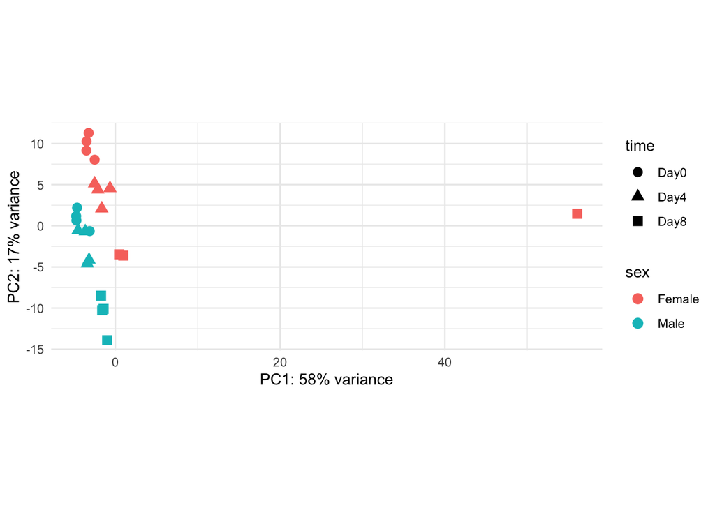

```r
dds2 <- DESeq2::DESeqDataSet(se[, se$tissue == "Spinalcord"],
                            design = ~ sex + time)
vsd <- DESeq2::vst(dds2, blind = TRUE)
pcaData <- DESeq2::plotPCA(vsd, intgroup = c("sex", "time"),
                           returnData = TRUE)
percentVar <- round(100 * attr(pcaData, "percentVar"))
ggplot(pcaData, aes(x = PC1, y = PC2)) +
    geom_point(aes(color = sex, shape = time), size = 3) +
    theme_minimal() +
    xlab(paste0("PC1: ", percentVar[1], "% variance")) +
    ylab(paste0("PC2: ", percentVar[2], "% variance")) +
    coord_fixed()
```

```r
Glimma::glimmaMDS(dds2, top = 5000)
```

[interactive chart not shown]

# Paired mouse data

Although it often is best to analyze different tissues separately, the cerebellum and spinalcord samples did come from the same mice (although a few samples were lost) nested within time. This could be useful to teach a paired analysis, although likely would be best to reduce the number of factors. Females at Day 0 and Day 4 has all 4 replicates with both tissues.

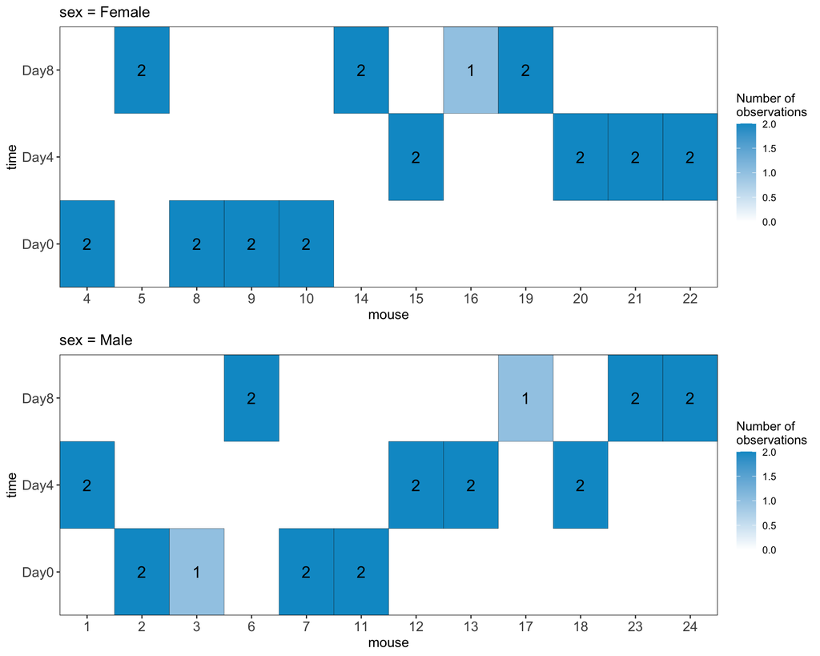

```r
res2 <- ExploreModelMatrix::VisualizeDesign(sampleData = colData(se),
                                           designFormula = ~ sex + time + mouse)
cowplot::plot_grid(plotlist = res2$cooccurrenceplots, nrow = 2)
```

```r
dds3 <- DESeq2::DESeqDataSet(se[, se$sex == "Female" & se$time %in% c("Day0","Day4")],
                            design = ~ time + tissue)
```

```
## factor levels were dropped which had no samples
```

```r
Glimma::glimmaMDS(dds3, top = 5000)
```

[interactive chart not shown]